# AQ 224 – Plankton Systematics and Ecology

Ocean Division and Zones

Nyamisi Peter

2026-04-16

# Ocean Division and Zones

## Overview of Ocean Division

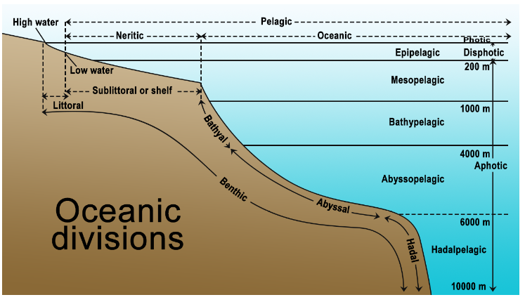

Ocean Divisions

## Overview of Ocean Division

- The ocean environment is divided based on:
  - **Depth** (vertical zones)
  - **Distance from shore** (horizontal zones)
- These divisions help us understand the distribution of plankton and marine organisms
- Each zone has unique characteristics affecting life forms

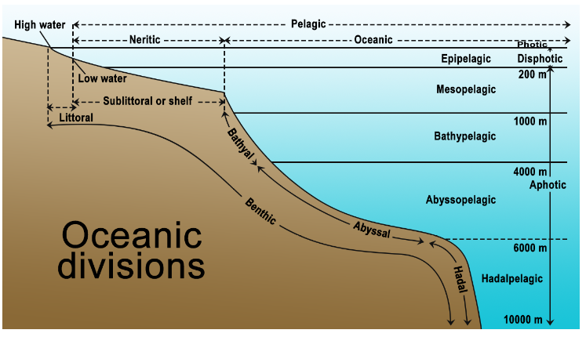

Ocean Divisions

## Vertical Zones: Pelagic Division

- **Pelagic zone:** The entire water column (open water)
- Divided into distinct depth zones based on **light penetration** and **pressure**

## Epipelagic Zone (Sunlight Zone)

- **Depth:** 0-200 meters
- **Characteristics:**
  - Receives sunlight
  - Warmest zone
  - Supports photosynthesis
  - Highest biodiversity
  - Dissolved oxygen abundant
- **Plankton:** Rich in phytoplankton and zooplankton
- **Importance:** Primary production occurs here

## Mesopelagic Zone (Twilight Zone)

- **Depth:** 200-1000 meters
- **Characteristics:**
  - Dim light (partial darkness)
  - Twilight conditions (not enough for photosynthesis)
  - Rapid temperature decrease
  - Lower photosynthesis
- **Plankton:** Specialized zooplankton adapted to low light
- **Organisms:** Bioluminescent species common

## Horizontal Zones: Neritic vs. Oceanic

### **Neritic Province:**

- Shallow water above the continental shelf
- Extends 200+ km from shore
- High nutrient availability
- High productivity
- Supports rich plankton communities

### **Oceanic Province:**

- Deep water beyond the continental shelf
- Low nutrient availability (except upwelling zones)
- Lower productivity in many regions
- Unique specialized plankton

## Benthic Division

- **Benthic zone:** The seafloor and organisms living on/in it
- Divided by depth:
  - **Supralittoral** – Above high tide
  - **Littoral** – Intertidal zone
  - **Sublittoral** – Continental shelf (< 200 m)
  - **Abyssal** – Deep ocean floor
- Meroplankton larvae settle in benthic zones

## Key Factors Affecting Ocean Zones

| Factor | Impact |
| --- | --- |
| **Light** | Enables photosynthesis; affects animal behavior |
| **Temperature** | Controls metabolic rates and organism distribution |
| **Pressure** | Affects gas solubility and organism physiology |
| **Dissolved Oxygen** | Essential for respiration; varies by depth |
| **Nutrients** | Crucial for primary production; limits growth |
| **Salinity** | Affects osmotic balance in organisms |

## Plankton Distribution by Zone

**Epipelagic:**

- Rich plankton communities
- Maximum phytoplankton
- Diverse zooplankton
- Larval forms

**Mesopelagic:**

- Deep-sea copepods
- Larval fishes
- Myctophids (lanternfish)

**Bathypelagic:**

- Specialized zooplankton
- Detritus feeders
- Bioluminescent species

**Hadopelagic:**

- Hadal amphipods
- Sparse copepods
- Specialized bacteria

## Importance of Ocean Divisions

- **Scientific Understanding:**
  - Predicting organism distribution
  - Understanding adaptation strategies
  - Tracking nutrient cycling
- **Conservation:**
  - Managing marine resources
  - Understanding climate impacts
  - Protecting biodiversity
- **Fisheries:**
  - Locating commercial species
  - Sustainable harvest practices

## Summary

- Ocean divisions provide a framework for understanding marine ecosystems
- **Vertical divisions** (epipelagic, mesopelagic, bathypelagic, hadopelagic) depend on depth and light
- **Horizontal divisions** (neritic, oceanic) depend on distance from shore
- Each zone has unique physical conditions
- Plankton distributions reflect these environmental gradients